# Analise de dados de uma empresa de compartilhamento de bicicletas

Eduardo Lisboa

2025-04-15

#Análise de dados de viagem com bicicletas alugadas

##Será iniciada a análise dos dados públicos fornecidos em plataformas de estudo, estes dados contém em sua estrutura trajetos, tipos de usuario, locais e datas de início e chegada

###O arquivo tem o formato .csv

###Utilizaresmos o nome fictício de Cyclist para nos referirmos à empresa em questão

Bibliotecas utilizadas para análise e manipulação dos dados:

```r
    library(tidyverse)
    library(ggplot2)
```

Carregando os dados para um novo dataframe:

```r
    q1_2019 <- read_csv("Divvy_Trips_2019_Q1.csv")
    q1_2020 <- read_csv("Divvy_Trips_2020_Q1.csv")
```

Utilizaremos os dados referentes ao 1° trimestre de 2019 e 1° trimestre de 2020

Visualizando parte das informações e as características das colunas dos dados

```r
    head(q1_2019)
```

```
## # A tibble: 6 × 12
##    trip_id start_time          end_time            bikeid tripduration
##      <dbl> <dttm>              <dttm>               <dbl>        <dbl>
## 1 21742443 2019-01-01 00:04:37 2019-01-01 00:11:07   2167          390
## 2 21742444 2019-01-01 00:08:13 2019-01-01 00:15:34   4386          441
## 3 21742445 2019-01-01 00:13:23 2019-01-01 00:27:12   1524          829
## 4 21742446 2019-01-01 00:13:45 2019-01-01 00:43:28    252         1783
## 5 21742447 2019-01-01 00:14:52 2019-01-01 00:20:56   1170          364
## 6 21742448 2019-01-01 00:15:33 2019-01-01 00:19:09   2437          216
## # ℹ 7 more variables: from_station_id <dbl>, from_station_name <chr>,
## #   to_station_id <dbl>, to_station_name <chr>, usertype <chr>, gender <chr>,
## #   birthyear <dbl>
```

```r
    head(q1_2020)
```

```
## # A tibble: 6 × 13
##   ride_id          rideable_type started_at          ended_at
##   <chr>            <chr>         <dttm>              <dttm>
## 1 EACB19130B0CDA4A docked_bike   2020-01-21 20:06:59 2020-01-21 20:14:30
## 2 8FED874C809DC021 docked_bike   2020-01-30 14:22:39 2020-01-30 14:26:22
## 3 789F3C21E472CA96 docked_bike   2020-01-09 19:29:26 2020-01-09 19:32:17
## 4 C9A388DAC6ABF313 docked_bike   2020-01-06 16:17:07 2020-01-06 16:25:56
## 5 943BC3CBECCFD662 docked_bike   2020-01-30 08:37:16 2020-01-30 08:42:48
## 6 6D9C8A6938165C11 docked_bike   2020-01-10 12:33:05 2020-01-10 12:37:54
## # ℹ 9 more variables: start_station_name <chr>, start_station_id <dbl>,
## #   end_station_name <chr>, end_station_id <dbl>, start_lat <dbl>,
## #   start_lng <dbl>, end_lat <dbl>, end_lng <dbl>, member_casual <chr>
```

```r
    colnames(q1_2019)
```

```
##  [1] "trip_id"           "start_time"        "end_time"
##  [4] "bikeid"            "tripduration"      "from_station_id"
##  [7] "from_station_name" "to_station_id"     "to_station_name"
## [10] "usertype"          "gender"            "birthyear"
```

```r
    colnames(q1_2020)
```

```
##  [1] "ride_id"            "rideable_type"      "started_at"
##  [4] "ended_at"           "start_station_name" "start_station_id"
##  [7] "end_station_name"   "end_station_id"     "start_lat"
## [10] "start_lng"          "end_lat"            "end_lng"
## [13] "member_casual"
```

Percebemos que os dois datasets tem nomes e numero de colunas diferentes, mas que representam a mesma informação, deste modo temos que identificar as colunas com mesmo tipo de informação para melhorarmos nosso dataframe

Vamos alterar o nome das colunas do q1 2019 para os mesmos nomes contidos em q1_2020

```r
    q1_2019 <- rename(q1_2019, ride_id = trip_id, rideable_type = bikeid, start_station_name = from_station_name, member_casual = usertype, started_at = start_time, ended_at = end_time, start_station_id = from_station_id, end_station_name = to_station_name, end_station_id = to_station_id)
```

Verificando se a alteração foi feita

```r
    str(q1_2019)
```

```
## spc_tbl_ [365,069 × 12] (S3: spec_tbl_df/tbl_df/tbl/data.frame)
##  $ ride_id           : num [1:365069] 21742443 21742444 21742445 21742446 21742447 ...
##  $ started_at        : POSIXct[1:365069], format: "2019-01-01 00:04:37" "2019-01-01 00:08:13" ...
##  $ ended_at          : POSIXct[1:365069], format: "2019-01-01 00:11:07" "2019-01-01 00:15:34" ...
##  $ rideable_type     : num [1:365069] 2167 4386 1524 252 1170 ...
##  $ tripduration      : num [1:365069] 390 441 829 1783 364 ...
##  $ start_station_id  : num [1:365069] 199 44 15 123 173 98 98 211 150 268 ...
##  $ start_station_name: chr [1:365069] "Wabash Ave & Grand Ave" "State St & Randolph St" "Racine Ave & 18th St" "California Ave & Milwaukee Ave" ...
##  $ end_station_id    : num [1:365069] 84 624 644 176 35 49 49 142 148 141 ...
##  $ end_station_name  : chr [1:365069] "Milwaukee Ave & Grand Ave" "Dearborn St & Van Buren St (*)" "Western Ave & Fillmore St (*)" "Clark St & Elm St" ...
##  $ member_casual     : chr [1:365069] "Subscriber" "Subscriber" "Subscriber" "Subscriber" ...
##  $ gender            : chr [1:365069] "Male" "Female" "Female" "Male" ...
##  $ birthyear         : num [1:365069] 1989 1990 1994 1993 1994 ...
##  - attr(*, "spec")=
##   .. cols(
##   ..   trip_id = col_double(),
##   ..   start_time = col_datetime(format = ""),
##   ..   end_time = col_datetime(format = ""),
##   ..   bikeid = col_double(),
##   ..   tripduration = col_number(),
##   ..   from_station_id = col_double(),
##   ..   from_station_name = col_character(),
##   ..   to_station_id = col_double(),
##   ..   to_station_name = col_character(),
##   ..   usertype = col_character(),
##   ..   gender = col_character(),
##   ..   birthyear = col_double()
##   .. )
##  - attr(*, "problems")=<externalptr>
```

```r
    str(q1_2020)
```

```
## spc_tbl_ [426,887 × 13] (S3: spec_tbl_df/tbl_df/tbl/data.frame)
##  $ ride_id           : chr [1:426887] "EACB19130B0CDA4A" "8FED874C809DC021" "789F3C21E472CA96" "C9A388DAC6ABF313" ...
##  $ rideable_type     : chr [1:426887] "docked_bike" "docked_bike" "docked_bike" "docked_bike" ...
##  $ started_at        : POSIXct[1:426887], format: "2020-01-21 20:06:59" "2020-01-30 14:22:39" ...
##  $ ended_at          : POSIXct[1:426887], format: "2020-01-21 20:14:30" "2020-01-30 14:26:22" ...
##  $ start_station_name: chr [1:426887] "Western Ave & Leland Ave" "Clark St & Montrose Ave" "Broadway & Belmont Ave" "Clark St & Randolph St" ...
##  $ start_station_id  : num [1:426887] 239 234 296 51 66 212 96 96 212 38 ...
##  $ end_station_name  : chr [1:426887] "Clark St & Leland Ave" "Southport Ave & Irving Park Rd" "Wilton Ave & Belmont Ave" "Fairbanks Ct & Grand Ave" ...
##  $ end_station_id    : num [1:426887] 326 318 117 24 212 96 212 212 96 100 ...
##  $ start_lat         : num [1:426887] 42 42 41.9 41.9 41.9 ...
##  $ start_lng         : num [1:426887] -87.7 -87.7 -87.6 -87.6 -87.6 ...
##  $ end_lat           : num [1:426887] 42 42 41.9 41.9 41.9 ...
##  $ end_lng           : num [1:426887] -87.7 -87.7 -87.7 -87.6 -87.6 ...
##  $ member_casual     : chr [1:426887] "member" "member" "member" "member" ...
##  - attr(*, "spec")=
##   .. cols(
##   ..   ride_id = col_character(),
##   ..   rideable_type = col_character(),
##   ..   started_at = col_datetime(format = ""),
##   ..   ended_at = col_datetime(format = ""),
##   ..   start_station_name = col_character(),
##   ..   start_station_id = col_double(),
##   ..   end_station_name = col_character(),
##   ..   end_station_id = col_double(),
##   ..   start_lat = col_double(),
##   ..   start_lng = col_double(),
##   ..   end_lat = col_double(),
##   ..   end_lng = col_double(),
##   ..   member_casual = col_character()
##   .. )
##  - attr(*, "problems")=<externalptr>
```

Convertendo o tipo da informação das colunas para evitar erros

```r
    q1_2019 <- mutate(q1_2019, ride_id = as.character(ride_id), rideable_type = as.character(rideable_type))
```

Iremos juntar os dados dos dois dataframes em um único dataset

```r
    all_trips <- bind_rows(q1_2019, q1_2020)
```

Vamos separar apenas os dados que consideramos mais importantes para nossa análise

```r
    all_trips <- all_trips %>% select(-c(start_lat, start_lng, end_lat, end_lng, birthyear, gender, "tripduration"))
```

Checando as caracteristicas do novo dataframe, para verifica se foi criado corretamente com as tabelas e caracteristicas que especificamos anteriormente

```r
    head(all_trips)
```

```
## # A tibble: 6 × 9
##   ride_id started_at          ended_at            rideable_type start_station_id
##   <chr>   <dttm>              <dttm>              <chr>                    <dbl>
## 1 217424… 2019-01-01 00:04:37 2019-01-01 00:11:07 2167                       199
## 2 217424… 2019-01-01 00:08:13 2019-01-01 00:15:34 4386                        44
## 3 217424… 2019-01-01 00:13:23 2019-01-01 00:27:12 1524                        15
## 4 217424… 2019-01-01 00:13:45 2019-01-01 00:43:28 252                        123
## 5 217424… 2019-01-01 00:14:52 2019-01-01 00:20:56 1170                       173
## 6 217424… 2019-01-01 00:15:33 2019-01-01 00:19:09 2437                        98
## # ℹ 4 more variables: start_station_name <chr>, end_station_id <dbl>,
## #   end_station_name <chr>, member_casual <chr>
```

```r
    colnames(all_trips)
```

```
## [1] "ride_id"            "started_at"         "ended_at"
## [4] "rideable_type"      "start_station_id"   "start_station_name"
## [7] "end_station_id"     "end_station_name"   "member_casual"
```

```r
    nrow(all_trips)
```

```
## [1] 791956
```

```r
    dim(all_trips)
```

```
## [1] 791956      9
```

```r
    str(all_trips)
```

```
## tibble [791,956 × 9] (S3: tbl_df/tbl/data.frame)
##  $ ride_id           : chr [1:791956] "21742443" "21742444" "21742445" "21742446" ...
##  $ started_at        : POSIXct[1:791956], format: "2019-01-01 00:04:37" "2019-01-01 00:08:13" ...
##  $ ended_at          : POSIXct[1:791956], format: "2019-01-01 00:11:07" "2019-01-01 00:15:34" ...
##  $ rideable_type     : chr [1:791956] "2167" "4386" "1524" "252" ...
##  $ start_station_id  : num [1:791956] 199 44 15 123 173 98 98 211 150 268 ...
##  $ start_station_name: chr [1:791956] "Wabash Ave & Grand Ave" "State St & Randolph St" "Racine Ave & 18th St" "California Ave & Milwaukee Ave" ...
##  $ end_station_id    : num [1:791956] 84 624 644 176 35 49 49 142 148 141 ...
##  $ end_station_name  : chr [1:791956] "Milwaukee Ave & Grand Ave" "Dearborn St & Van Buren St (*)" "Western Ave & Fillmore St (*)" "Clark St & Elm St" ...
##  $ member_casual     : chr [1:791956] "Subscriber" "Subscriber" "Subscriber" "Subscriber" ...
```

```r
    summary(all_trips)
```

```
##    ride_id            started_at
##  Length:791956      Min.   :2019-01-01 00:04:37.00
##  Class :character   1st Qu.:2019-02-28 17:04:04.75
##  Mode  :character   Median :2020-01-07 12:48:50.50
##                     Mean   :2019-09-01 11:58:08.35
##                     3rd Qu.:2020-02-19 19:31:54.75
##                     Max.   :2020-03-31 23:51:34.00
##
##     ended_at                      rideable_type      start_station_id
##  Min.   :2019-01-01 00:11:07.00   Length:791956      Min.   :  2.0
##  1st Qu.:2019-02-28 17:15:58.75   Class :character   1st Qu.: 77.0
##  Median :2020-01-07 13:02:50.00   Mode  :character   Median :174.0
##  Mean   :2019-09-01 12:17:52.17                      Mean   :204.4
##  3rd Qu.:2020-02-19 19:51:54.50                      3rd Qu.:291.0
##  Max.   :2020-05-19 20:10:34.00                      Max.   :675.0
##
##  start_station_name end_station_id  end_station_name   member_casual
##  Length:791956      Min.   :  2.0   Length:791956      Length:791956
##  Class :character   1st Qu.: 77.0   Class :character   Class :character
##  Mode  :character   Median :174.0   Mode  :character   Mode  :character
##                     Mean   :204.4
##                     3rd Qu.:291.0
##                     Max.   :675.0
##                     NA's   :1
```

Ao visualizarmos os dados, foi identificado que a coluna member_casual contém 4 tipos de dados no lugar de apenas 2, dessa forma a seguir iremos identificar quais dados podem ter sua descrição corrigida

```r
    table(all_trips$member_casual)
```

```
##
##     casual   Customer     member Subscriber
##      48480      23163     378407     341906
```

Alterando os dados de maneira a limitar a 2 tipos, pois os outros 2 tipos descrevem a mesma informação, apenas de maneira diferente

```r
    all_trips <- all_trips %>%
    mutate(member_casual = recode(member_casual, "Subscriber" = "member", "Customer" = "casual"))
```

Verificando se foi feito corretamente

```r
    table(all_trips$member_casual)
```

```
##
## casual member
##  71643 720313
```

Para um melhor resultado no plot dos dados, iremos separar o campo data, em outros campos, como dia da semana, duração, mes, ano, dia

```r
    all_trips$date <- as.Date(all_trips$started_at)
    all_trips$month <- format(as.Date(all_trips$date), "%m")
    all_trips$day <- format(as.Date(all_trips$date), "%d")
    all_trips$year <- format(as.Date(all_trips$date), "%Y")
    all_trips$day_of_week <- format(as.Date(all_trips$date), "%A", locale = "C")
    all_trips$ride_length <- difftime(all_trips$ended_at, all_trips$started_at)
```

Agora temos que converter o tipo de informação apresentada para realizarmos calculos

```r
    str(all_trips)
```

```
## tibble [791,956 × 15] (S3: tbl_df/tbl/data.frame)
##  $ ride_id           : chr [1:791956] "21742443" "21742444" "21742445" "21742446" ...
##  $ started_at        : POSIXct[1:791956], format: "2019-01-01 00:04:37" "2019-01-01 00:08:13" ...
##  $ ended_at          : POSIXct[1:791956], format: "2019-01-01 00:11:07" "2019-01-01 00:15:34" ...
##  $ rideable_type     : chr [1:791956] "2167" "4386" "1524" "252" ...
##  $ start_station_id  : num [1:791956] 199 44 15 123 173 98 98 211 150 268 ...
##  $ start_station_name: chr [1:791956] "Wabash Ave & Grand Ave" "State St & Randolph St" "Racine Ave & 18th St" "California Ave & Milwaukee Ave" ...
##  $ end_station_id    : num [1:791956] 84 624 644 176 35 49 49 142 148 141 ...
##  $ end_station_name  : chr [1:791956] "Milwaukee Ave & Grand Ave" "Dearborn St & Van Buren St (*)" "Western Ave & Fillmore St (*)" "Clark St & Elm St" ...
##  $ member_casual     : chr [1:791956] "member" "member" "member" "member" ...
##  $ date              : Date[1:791956], format: "2019-01-01" "2019-01-01" ...
##  $ month             : chr [1:791956] "01" "01" "01" "01" ...
##  $ day               : chr [1:791956] "01" "01" "01" "01" ...
##  $ year              : chr [1:791956] "2019" "2019" "2019" "2019" ...
##  $ day_of_week       : chr [1:791956] "terça-feira" "terça-feira" "terça-feira" "terça-feira" ...
##  $ ride_length       : 'difftime' num [1:791956] 390 441 829 1783 ...
##   ..- attr(*, "units")= chr "secs"
```

```r
    is.factor(all_trips$ride_length)
```

```
## [1] FALSE
```

```r
    is.numeric(all_trips$ride_length)
```

```
## [1] FALSE
```

```r
    all_trips$ride_length <- as.numeric(as.character(all_trips$ride_length))
    is.numeric(all_trips$ride_length)
```

```
## [1] TRUE
```

Criando um novo dataframe, onde eliminaremos os usos da bicicleta que foram considerados testes ou manutenção que foi identificada pela sigla “HQ QR”

```r
    all_trips_v2 <- all_trips[!(all_trips$start_station_name == "HQ QR" | all_trips$ride_length < 0),]
    summary(all_trips_v2$ride_length)
```

```
##     Min.  1st Qu.   Median     Mean  3rd Qu.     Max.
##        1      331      539     1189      912 10632022
```

Calculando alguns indicadores comparando a duração do uso com o tipo de membro

```r
    aggregate(all_trips_v2$ride_length ~ all_trips_v2$member_casual, FUN = mean)
```

```
##   all_trips_v2$member_casual all_trips_v2$ride_length
## 1                     casual                5372.7839
## 2                     member                 795.2523
```

```r
    aggregate(all_trips_v2$ride_length ~ all_trips_v2$member_casual, FUN = median)
```

```
##   all_trips_v2$member_casual all_trips_v2$ride_length
## 1                     casual                     1393
## 2                     member                      508
```

```r
    aggregate(all_trips_v2$ride_length ~ all_trips_v2$member_casual, FUN = max)
```

```
##   all_trips_v2$member_casual all_trips_v2$ride_length
## 1                     casual                 10632022
## 2                     member                  6096428
```

```r
    aggregate(all_trips_v2$ride_length ~ all_trips_v2$member_casual, FUN = min)
```

```
##   all_trips_v2$member_casual all_trips_v2$ride_length
## 1                     casual                        2
## 2                     member                        1
```

Calculando e separando por dia da semana

```r
    aggregate(all_trips_v2$ride_length ~ all_trips_v2$member_casual + all_trips_v2$day_of_week, FUN = mean)
```

```
##    all_trips_v2$member_casual all_trips_v2$day_of_week all_trips_v2$ride_length
## 1                      casual                  domingo                5061.3044
## 2                      member                  domingo                 972.9383
## 3                      casual             quarta-feira                4480.3724
## 4                      member             quarta-feira                 711.9838
## 5                      casual             quinta-feira                8451.6669
## 6                      member             quinta-feira                 707.2093
## 7                      casual                   sábado                4950.7708
## 8                      member                   sábado                 974.0730
## 9                      casual            segunda-feira                4752.0504
## 10                     member            segunda-feira                 822.3112
## 11                     casual              sexta-feira                6090.7373
## 12                     member              sexta-feira                 796.7338
## 13                     casual              terça-feira                4561.8039
## 14                     member              terça-feira                 769.4416
```

Definindo níveis e ordenando por dia da semana, pois anteriormente os dados não estavam em ordem

```r
    all_trips_v2$day_of_week <- ordered(all_trips_v2$day_of_week, levels=c("domingo", "segunda-feira", "terça-feira", "quarta-feira", "quinta-feira", "sexta-feira", "sábado"))
```

Verificando as alterações anteriores

```r
    aggregate(all_trips_v2$ride_length ~ all_trips_v2$member_casual + all_trips_v2$day_of_week, FUN = mean)
```

```
##    all_trips_v2$member_casual all_trips_v2$day_of_week all_trips_v2$ride_length
## 1                      casual                  domingo                5061.3044
## 2                      member                  domingo                 972.9383
## 3                      casual            segunda-feira                4752.0504
## 4                      member            segunda-feira                 822.3112
## 5                      casual              terça-feira                4561.8039
## 6                      member              terça-feira                 769.4416
## 7                      casual             quarta-feira                4480.3724
## 8                      member             quarta-feira                 711.9838
## 9                      casual             quinta-feira                8451.6669
## 10                     member             quinta-feira                 707.2093
## 11                     casual              sexta-feira                6090.7373
## 12                     member              sexta-feira                 796.7338
## 13                     casual                   sábado                4950.7708
## 14                     member                   sábado                 974.0730
```

alterando nosso dataframe para criar uma nova coluna e extrair o valor de weekday, agrupando e calculando a quantidade média por dia da semana de viagens separando por tipo de membro

```r
    all_trips_v2 %>%
    mutate(weekday = wday(started_at, label = TRUE)) %>%
    group_by(member_casual, weekday) %>%
    summarize(number_of_rides = n(), average_duration = mean (ride_length)) %>%
    arrange(member_casual, weekday)
```

```
## # A tibble: 14 × 4
## # Groups:   member_casual [2]
##    member_casual weekday number_of_rides average_duration
##    <chr>         <ord>             <int>            <dbl>
##  1 casual        dom               18652            5061.
##  2 casual        seg                5591            4752.
##  3 casual        ter                7311            4562.
##  4 casual        qua                7690            4480.
##  5 casual        qui                7147            8452.
##  6 casual        sex                8013            6091.
##  7 casual        sáb               13473            4951.
##  8 member        dom               60197             973.
##  9 member        seg              110430             822.
## 10 member        ter              127974             769.
## 11 member        qua              121902             712.
## 12 member        qui              125228             707.
## 13 member        sex              115168             797.
## 14 member        sáb               59413             974.
```

Criando um grafico de colunas com a quantidade de uso da bicicletas separados por dia da semana, preenchido por tipo de usuario

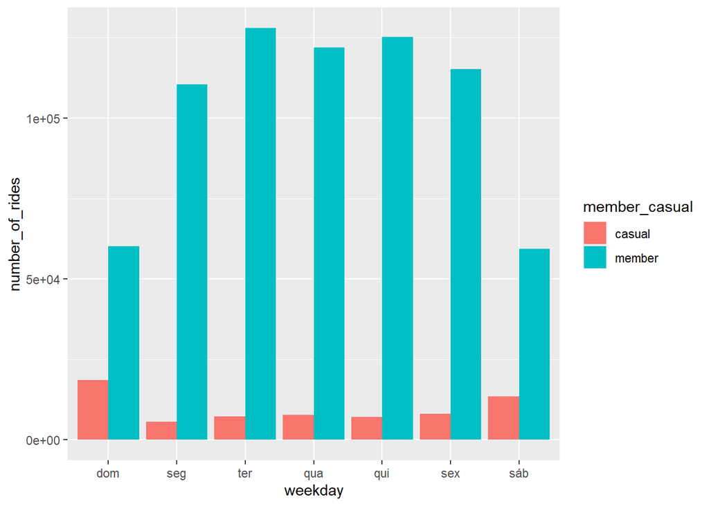

```r
    all_trips_v2 %>%
    mutate(weekday = wday(started_at, label = TRUE)) %>%
    group_by(member_casual, weekday) %>%
    summarise(number_of_rides = n(), average_duration = mean(ride_length)) %>%
    arrange(member_casual, weekday) %>%
    ggplot(aes(x = weekday, y = number_of_rides, fill = member_casual)) + geom_col(position = "dodge")
```

Desta vez criamos um grafico de barras que informa a duração média do uso das bicicletas por dia da semana e preenchido pelo tipo de membro

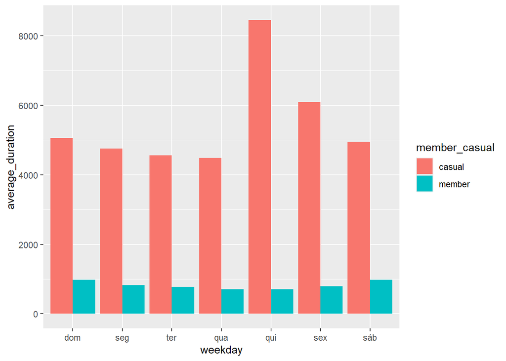

```r
    all_trips_v2 %>%
    mutate(weekday = wday(started_at, label = TRUE)) %>%
    group_by(member_casual, weekday) %>%
    summarise(number_of_rides = n(), average_duration = mean(ride_length)) %>%
    arrange(member_casual, weekday) %>%
    ggplot(aes(x = weekday, y = average_duration, fill = member_casual)) + geom_col(position = "dodge")
```

Com este bloco de código podemos separar os dados que utilizamos nos graficos anteriores em um novo dataframe para que possamos utiliza-los em outras análises

```r
    counts <- aggregate(all_trips_v2$ride_length ~ all_trips_v2$member_casual + all_trips_v2$day_of_week, FUN = mean)
    write_csv(counts, file = "avg_ride_length.csv")
    summary(all_trips_v2$ride_length)
    unique(all_trips_v2$member_casual)
    unique(all_trips_v2$day_of_week)
    head(all_trips_v2$day_of_week)
```

[output not shown]

##Conclusão da análise Podemos observar ao focar nos tipos de usuário e seus hábitos de uso das bicicletas durante a semana que há diferênça de comportamento, entre “pessoas que pagam a assinatura” e “pessoas que utilizam casualmente”, de modo a verificar padrões de comportamento que podem ser utilizados para campanhas publicitarias focadas em aumentar o número de assinaturas em determinado tipo de usuário de modo a trazer benefício mútuo para usuário e empresa.